```python
import numpy as np # Libreria para analisis númerico

import pandas as pd  # Libreria para analisis de datos

import sympy as sp  # Libreria para analisis simbolico
from sympy import *
from sympy.interactive import printing
from sympy.abc import x, y, t
from ipywidgets import interact

import matplotlib
import matplotlib.pyplot as plt
import matplotlib.animation as animation
# import seaborn as sns # obcional en vez de matplolib
# import glob # para buscar un archivo con un nombre de archivo específico

# Librerias para contenido de la presentaAbsción
from IPython.display import Image
from IPython.display import YouTubeVideo
from IPython.display import IFrame
from IPython.display import display
from IPython.display import Latex
# \textit para texto en cursiva, \textbf para texto en negrita y \textsf para tipo de letra sans serif.
# \mathcal{F}
# \mathbb{N}
# \mathfrak{G}
# \mathrm{si}
# \mathit{si}
# \mathsf{si}

printing.init_printing(use_latex='mathjax') # imprimir con notación matemática.
```

# ***Ecuaciones diferenciales***

[figure not shown]

$$\quad\nonumber$$$$\quad\nonumber$$

*Dr. Felipe de Jesús Tlachino Macuitl*

*felipe.tlachino459@uppuebla.edu.mx*</font>

$\quad$**[Classroom](https://classroom.google.com/h)**</font>

$\qquad\qquad\\qquad\$ **[Examen de diagnóstico](https://quizizz.com/admin/quiz/6264bc5d8fa74b001d985cba/ecuaciones-diferenciales)**

**Contenido**

- **Introducción a las ecuaciones diferenciales**
- **Ecuaciones diferenciales ordinarias de primer orden**
- **Ecuaciones diferenciales ordinarias de orden superior**
- **Transformada de Laplace**
- **Sistemas de ecuaciones diferenciales**

**Bibliografia:**

$ \quad\ [1] \quad\ $ Zill, D. G., Cullen, M. R., Hernández, A. E. G., & López, E. F. (2002). Ecuaciones diferenciales con problemas de valores en la frontera. Thomson.

$ \quad\ [2] \quad\ $ Abell, M. L., & Braselton, J. P. (2022). Differential equations with Mathematica. Academic Press.

$ \quad\ [3] \quad\ $ Introduction to Differential Equations, https://www.wolfram.com/wolfram-u/introduction-to-differential-equations/

## **Introducción a las ecuaciones diferenciales**

**Nota**: *El estudio de las ecuaciones diferenciales es una parte de la Matemática que, quizá más que cualquier otra, ha sido directamente inspirada por la Mecánica, la Astronomía y la Física matemática. Su historia empezó en el siglo XVII cuando Newton, Leibniz y los Bernoulli resolvieron algunas ecuaciones diferenciales sencillas que se presentaron en problemas de Geometría y Mecánica.*

- **¿Qué es una ecuación diferencial?**
- **Tipos de ecuaciones diferenciales**
- **Sistemas de ecuaciones diferenciales**
- **Solucion de ecuaciones diferenciales**
- **Condiciones iniciales y valores en la frontera**

### **¿Qué es una ecuación diferencial?**

Para una gran variedad de problemas se desea determinar un elemento variable a partir de su coeficiente de variación.

**Ejemplo**: *Siendo $P=𝑃(𝑡)$ el tamaño de la población en el instante $t$, el modelo exponencial presupone que la tasa de aumento de la población es proporcional a la población en ese instante:* \begin{equation} \frac{dP}{dt} = k P \quad\ \text{Ecuación malthusiana} \nonumber \end{equation} *La ecuación malthusiana puede resultar adecuada cuando el tamaño de la población es pequeño en relación a las dimensiones del ecosistema y, en ese caso, $k$ representaría la tasa de aumento de la población que iguala a la tasa de natalidad menos la tasa de mortalidad.*

**Definición**: *Una **ecuación diferencial (ED)** es una ecuación que contiene la derivada o diferenciales de una o más variables dependientes con respecto a una o más variables independientes.*

### **Tipos de ecuaciones diferenciales**

* **Tipo** * *Ordinaria* * *Parcial* * **Orden** * **Linealidad**

\begin{equation*} \color{purple}{\text{ED}} \left\{ \begin{array}{ll} \color{orange}{\text{Ordinarias}}& \left\{ \begin{array}{ll} \color{cyan}{\text{Lineales}} & \left\{ \begin{array}{l} \color{purple}{\text{Homogéneas}} & \left\{ \begin{array}{l} \color{orange}{\text{Coeficientes Constantes}} \end{array} \right. \\ \color{purple}{\text{No Homogéneas}} \end{array} \right. \\ &\\ \color{cyan}{\text{No Lineales}} \end{array} \right. \\ & \\ \color{orange}{\text{Parciales}} \end{array} \right. \end{equation*}

**Definición**: *Si la ecuación contiene sólo derivadas (de una o más variables dependientes) con respecto a una sola variable independiente, la ecuación se llama **ecuación diferencial ordinaria (EDO)**.*

**Ejemplos**: \begin{equation} \ddot{\theta} + \frac{g}{L}\theta = 0, \quad\ P' = rP\left(1-\frac{P}{k}\right), \quad\ \frac{dx}{dt} + \frac{dy}{dt} = 2x + y, \quad\dots \nonumber \end{equation}

**Definición**: *Si la ecuación contiene derivadas parciales de una o más variables dependientes, entonces la ecuación se llama **ecuación diferencial parcial (EDP)**.*

**Ejemplos**: \begin{equation} \nabla^2 f=\frac{\partial^2 f}{\partial x^2} + \frac{\partial^2 f}{\partial y^2} + \frac{\partial^2 f}{\partial z^2} = 0, \quad\ \nabla\cdot\vec{J} = - \frac{\partial \rho}{\partial t}, \quad\dots \nonumber \end{equation}

**Definición**: *El **orden** de una ecuación diferencial (ya sea EDO o EDP) es el orden de la mayor derivada en la ecuación.*

**Ejemplos**: \begin{equation} T(t) = \frac{1}{2}m \left(\dot{x}\right)^2, \quad\ \ddot{\theta} + \frac{g}{L}\theta = 0, \quad\ \frac{d^2y}{x^2} + 5 \left(\frac{dy}{x}\right)^3 - 4 y= e^x, \quad\dots\nonumber \end{equation}

*Simbólicamente podemos expresar una ecuación diferencial ordinaria de orden $n$ con una variable dependiente por la **forma general**.* \begin{equation}\label{eq:eqd_fg} F(x, y, y' , . . . , y^{(n)}) = 0, \end{equation} *o por su **forma normal**.* \begin{equation}\label{eq:eqd_fn} \frac{d^n y}{dx^n} = f(x, y, y' , . . . , y^{(n-1)}) \end{equation}

**Definición**: *Una ecuación diferencial ordinaria (de orden $n$) es **lineal** si es de la forma:* \begin{equation}\label{eq:eqd_l} a_n(x)y^{(n)} + a_{n-1}(x)y^{(n-1)} + \cdots + a_1(x)y' + a_0(x)y + f(x) = 0 \end{equation} *donde las funciones $a_i(x),\, i = 0, 1, \dots, n$, y $f(x)$ están dados y $a_n(x)$ no es identicamente cero.*

*Dos casos especiales importantes de la ecuación (\ref{eq:eqd_l}) son las ED lineales de primer orden ($n = 1$) y de segundo orden ($n = 2$):* \begin{equation}\nonumber a_1(x)\frac{dy}{dx} + a_0(x)y = f(x) \quad\text{y}\quad\ a_2(x)\frac{d^2y}{dx^2} + a_1(x)\frac{dy}{dx} + a_0(x)y = f(x) \end{equation}

**Nota**: *Las dos propiedades características de una EDO lineal son las siguientes:* > *La variable dependiente $y$ y todas sus derivadas $y', y'', \dots , y^{(n)}$ son de primer grado, es decir, la potencia de cada término que contiene $y$ es igual a $1$.* > *Los coeficientes de $a_0, a_1, \dots , a_n$ de $y, y', \dots , y^{(n)}$ dependen a lo más de la variable independiente $x$.*

**Definición**: *Una ecuación diferencial ordinaria **no lineal** es simplemente no lineal, es decir, funciones no lineales de la variable dependiente o de sus derivadas.*

**Ejemplos**: \begin{equation} \color{blue}{(1-y)y'} + y = e^x, \quad\ \frac{d^2y}{dx^2} + \color{blue}{\sin(y)} = 0, \quad\ \frac{d^3y}{dx^3} + \color{blue}{y^2} = 0,\quad\dots \nonumber \end{equation}

**Definición**: *Si $f(x) = 0$, se dice que la ecuación (\ref{eq:eqd_l}) es una **ecuación diferencial lineal homogénea**.* \begin{equation}\label{eq:eqd_h} a_n(x)y^{(n)} + a_{n-1}(x)y^{(n-1)} + \cdots + a_1(x)y' + a_0(x)y = 0 \end{equation}

*Wolfram Language nos permite identificar que tipo de ED tenemos, esto mediante el comando **WolframAlpha**, de la siguiente manera:*

> WolframAlpha["ecuación diferencial",{{"ODEClassification",1},"Plaintext"}]

Para mostrar como funciona este comando, lo aplicaremos a la ED: $y''(t) = \big(y(t) t\big)^2$

```python
WolframAlpha["y''[t] == (y[t]*t)^2", {{"ODEClassification",1},"Plaintext"}]
```

```
second-order nonlinear ordinary differential equation
```

### **Sistemas de ecuaciones diferenciales**

**Definición**: *Un **sistema de ecuaciones diferenciales ordinarias** tiene dos o más ecuaciones que implican derivadas de dos o más funciones incógnitas de una sola variable independiente.*

**Ejemplo**: *Modelo depredador-presa de Lotka-Volterra* \begin{equation} \nonumber \left\{ \frac{dP}{dt} = r_1 P - a_1 PD \atop \frac{dD}{dt} = a_2 PD - r_2 D \right. \end{equation}

### **Solucion de ecuaciones diferenciales**

**Definición**: *Una **solución** a la ecuación diferencial ordinaria de orden $n$* \begin{equation} F(x, y, y', y'', \dots, y^{(n)}) = 0 \nonumber \end{equation} *en el intervalo $a < x < b$ es una función $\phi(x)$ que es continua en el intervalo $a < x < b$ y tiene todas las derivadas presentes en la ecuación diferencial tales que* \begin{equation} F(x, \phi(x), \phi'(x), \phi''(x), \dots, \phi^{(n)}(x)) = 0 \nonumber \end{equation} *en $a < x < b$.*

**Ejemplo**: *La ecuación diferencial $y' - y = 0$, tiene como solución $\phi(x) = C e^x$. Veamos que $\phi$ si es solución:* \begin{equation} \nonumber \text{Como } \phi(x) = C e^x \quad\Rightarrow\quad\ \phi'(x) = C e^x \atop \text{Por lo tanto si } y = \phi(x) \quad\Rightarrow\quad\ y' - y = 0 \end{equation}

*El lenguaje de programación de Wolfram Language nos permite comprobar si una función es solución de una ecuación diferencial. En este caso aplicaremos la función **Simplify**, la estructura de esta función es de la forma:*

> Simplify[ecuacion] $\quad\text{ o }\quad$ ecuacion//Simplify

```python
eqd = f'[x] - f[x] == 0;  (*de esta manera defino mi ecuación*)
f[x_] := C*e^x  (*de esta manera defino mi función solución*)
Simplify[eqd] (*Pedimos a wolfran que simplifique la ecuacion eqd con la función solución dada*)
```

```python
eqd//Simplify
```

```python
Simplify[eqd]/.Log[e] -> 1
```

[output not shown]

**Definición**:*Una solución en la cual la variable dependiente se expresa sólo en términos de la variable independiente y las constantes, $y=\phi(x)$, se dice que es una **solución explícita**.*

**Definición**: *Se dice que una relación $G(x, y) = 0$ es una **solución implícita** de una ecuación diferencial ordinaria (\ref{eq:eqd_fg}) en un intervalo $I$, suponiendo que existe al menos una función $\phi$ que satisface la relación así como la ecuación diferencial en el intervalo $I$.*

**Definición**: *Cuando resolvemos una ecuación diferencial de orden $n$ (\ref{eq:eqd_fg}), normalmente obtenemos una solución que contiene $n$ parámetros $(C_1, C_2, \dots, C_n)$. La solución que contiene estas constantes arbitrarias representa un conjunto, $G(x, y, C_1, C_2, \dots , C_n) = 0$, de soluciones llamado **familia de soluciones n-paramétrica**. Una solución de una ecuación diferencial que está libre de la elección de parámetros se llama **solución particular**.*

**Ejemplo**: *La ecuación diferencial $y' - y = 0$, tiene como solución $\phi(x) = C e^x$.* *Para ver la familia de soluciones podemos graficar la función $\phi(x) = C e^x$ con alunos valores para $C$.* *Para graficar usamos la función **Plot**. de la siguiente manera:* > Plot[f[x], {x, xmin, x,ax}]

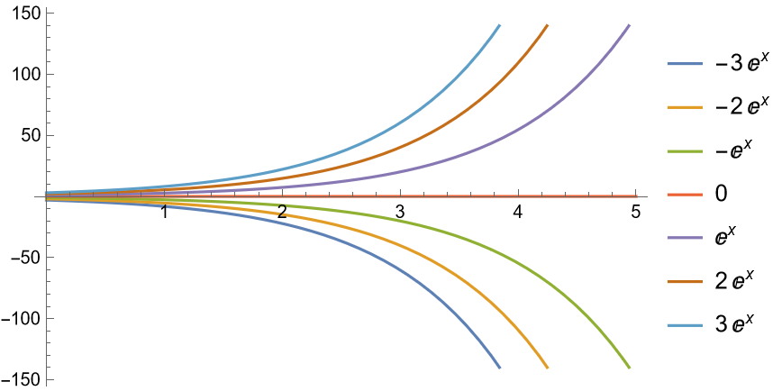

```python
Plot[Evaluate[C*Exp[x]/.C->Range[-3, 3]], {x, 0, 5}, PlotLegends->"Expressions"]
```

**Nota**: *Algunas veces una ecuación diferencial tiene una solución que no es miembro de una familia de soluciones de la ecuación, esto es, una solución que no se puede obtener usando un parámetro específico de la familia de soluciones. Esa solución extra se llama **solución singular**.*

**Nota**: *Una solución de una ecuación diferencial que es igual a cero en un intervalo $I$ se dice que es la **solución trivial**.*

**Ejemplo**: *La ecuación diferencial $y' = x\sqrt{y}$, tiene como soluciones $y = \frac{1}{16}(x^2 + C)^2$ y $y = 0$.*

*En Wolfram Language el comando **DSolve** se utiliza para resolver ED: su estructura es la siguiente*

> DSolve[ecuación diferencial, función incógnita, variable]

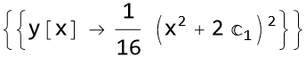

```python
DSolve[y'[x] == x*Sqrt[y[x]], y[x], x]//Simplify
```